# Galois theory: minimal notes

### **NOTES ON STATISTICS, PROBABILITY and MATHEMATICS**

### Minimal notes on Galois theory:

#### Extension Fields:

Adjoining one or all the roots of a polynomial creating a new field is a FOIL operation:

For instance, extending the field of rational numbers $\mathbb Q$ with $\sqrt 2$ to obtain a new field implies adding all the values of the form $a + b\sqrt 2.$ Now, if we add to this new field $\mathbb Q(\sqrt 2)$ the $\sqrt 3,$ the new extended field will have to contain $\alpha + \beta \sqrt 3$ with both $\alpha\in \mathbb Q(\sqrt 2)$ and $\beta \in \mathbb Q(\sqrt 2)$. Therefore,

$$\alpha + \beta \sqrt 3= (a + b\sqrt 2) +
(c + d\sqrt 2) \sqrt 3 = a + b \sqrt 2 + c \sqrt 3 + d \sqrt
6$$

Considering this field extension $\mathbb Q(\sqrt 2,\sqrt 3)$ as a vector field a set of basis can be $\{1,\sqrt 2, \sqrt 3, \sqrt 6\}.$ Therefore the extension has **degree** $4$.

Another way of getting the degree of the extension is the polynomial of the degree of the polynomial whose root is adjoined. This is multiplicative, so the polynomials in the case above are $x^2-2$ and $x^2 -3,$ both of degree $2,$ yielding the extension by the roots of both of them of degree $4.$ The mathematical notation for the degree of the extension $\mathbb Q(\sqrt 2)$ over $\mathbb Q,$ is $[\mathbb Q(\sqrt 2):\mathbb Q]=2.$

Given an algebraic root $r \notin F$, the **minimal polynomial** of $r$ over $F$ is the irreducible polynomial in $F[x]$ of which $r$ is a root. This is unique up to scalar multiplication. The **degree** of the extension $\mathbb Q (r)$ is the degree of the minimal polynomial of $r.$

The equivalent term for **degree** on the corresponding group lattice is term **index**: the index of a subgroup $H$ in a group $G$ is the number of left cosets of $H $ in $G$, or equivalently, the number of right cosets of $H$ in $G$. The index is denoted $[G:H]$.

##### Galois extension:

We say that an algebraic extension of a larger field $L$ over a base field $K$, i.e. $L/K,$ **is Galois** if $L$ is a **splitting field** of a separable polynomial with coefficients in $K$.

A **normal extension** is an algebraic field extension $L/K$ for which every irreducible polynomial over $K$ which has a root in $L$, splits into linear factors in $L.$ These are one of the conditions for algebraic extensions to be a Galois extension.

A **splitting field** of a polynomial with coefficients in a field is the smallest field extension of that field over which the polynomial splits, i.e., decomposes into linear factors.

In other words, to create a Galois extension all the roots of a polynomial should be included.

##### Automorphisms:

An automorphism is a bijection within the field that preserves the structure:

$$\phi(a + b) = \phi(a) +
\phi(b)$$

and

$$\phi(ab) = \phi(a) \phi(b)$$
Example:

Proving that in the field $\mathbb Q(\sqrt 2)$ the function

$$\begin{align} \mathbb Q(\sqrt 2) &
\to \mathbb Q(\sqrt 2)\\
\phi: a + b \sqrt2 &\mapsto a - b\sqrt2
\end{align}$$

is an automorphism requires proving:

$$\phi\left((a+b\sqrt2) + (c + d\sqrt 2)
\right)\overset{?}=\phi\left((a+b\sqrt2)\right) + \phi\left(c + d\sqrt
2)\right)$$

$$\phi\left((a+b\sqrt2) (c + d\sqrt 2)
\right)\overset{?}=\phi\left((a+b\sqrt2)\right) \phi\left(c + d\sqrt
2)\right)$$

and that it is a bijection.

The set of all automorphisms under composition is the **Galois group.** From Wikipedia:

Suppose that $E$ is an extension of the field $F$ (written as $E/F$ and read “E over F”). An automorphism of $E/F$ is defined to be an automorphism of $ E$ that fixes $F$ pointwise. In other words, an automorphism of $ E/F$ is an isomorphism $\alpha:E\to E$ such that $\alpha(x) = x$ for each $x\in F.$ The set of all automorphisms of $E/F$ forms a group with the operation of function composition. This group is sometimes denoted by $\text{Aut} (E/F).$ If $E/F$ is a Galois extension, then it is called the Galois group of $E/F,$ and is usually denoted by $\text{Gal} (E/F)$.

##### Fundamental theorem of Galois theory:

From Wikipedia:

Given a field extension $L/K$ that is finite and Galois, there is a one-to-one correspondence between its intermediate fields $L_0\supset\cdots \supset L_k$ and subgroups of its Galois group $1=𝐺_0<G_1<\cdots<G_k=G$.

For any subgroup $H$ of $\text{Gal}(L/K)$, the corresponding fixed field, denoted $L^H,$ is the set of those elements of $L$ which are fixed by every automorphism in $H.$

For any intermediate field $M$ of $L/K$, the corresponding subgroup is $\text{Aut}(L/M)$, that is, the set of those automorphisms in $\text{Gal}(L/K)$ which fix every element of $M.$

The fundamental theorem says that this correspondence is a one-to-one correspondence if (and only if) $L/K$ is a Galois extension. For example, the topmost field $L$ corresponds to the trivial subgroup of $\text{Gal}(L/K)$, and the base field $K$ corresponds to the whole group $\text{Gal}(L/K)$.

##### The quintic problem:

From Wikipedia:

A group G is called solvable if it has a subnormal series whose factor groups (quotient groups) are all abelian, that is, if there are subgroups $1 = G_0 < G_1 < ⋅⋅⋅ < G_k = G$ such that $G_{j−1}$ is normal in $G_j,$ and $G_j/G_{j−1}$ is an abelian group, for $j = 1, 2,\dots, k.$

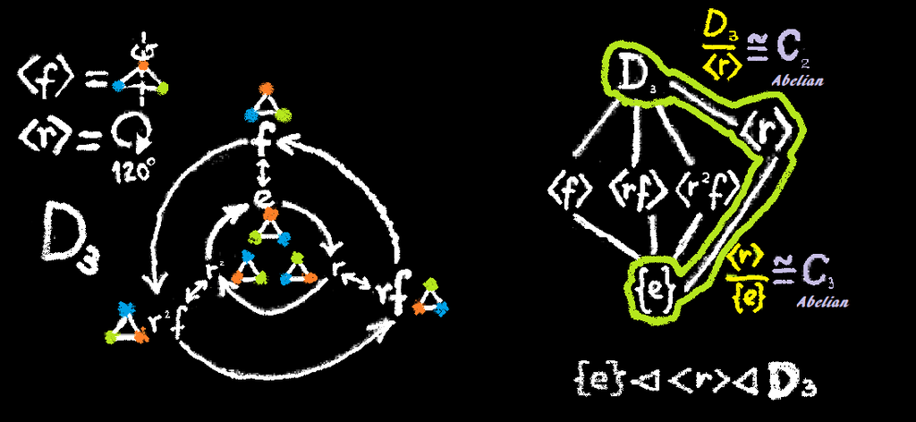

*On the image above, there are [two left cosets](https://youtu.be/R9D6iGo1d3M?si=OepHNaIbMXBttOgl&t=365) of the normal subgroup generated by $<r>$, i.e. $H =\{e,r,r^2\}\cong C_3$ of the dihedral group $G=D_3\cong S_3$, namely the subgroup itself, and $fH =\{f,fr,fr^2\}.$ Therefore, the quotient group $G/H$ ($G$ mod $H$) is $G/H=D_3/H\cong C_2\cong \mathbb Z_2$ or cyclic group of order $2.$*

The subgroups have to be normal to form quotient groups, i.e. set of cosets of a normal subgroup of a group.

Why does it have to be **abelian**? This is the key to understand Galois insolvability of the quintic. The relationship between abelian and solvable by radicals is explained, for instance, in [here](https://math.stackexchange.com/a/3753363/152225). In [this post](https://math.stackexchange.com/a/4509844/152225) it seems to imply that we can think of abelian as cyclic in the context of finite groups:

A group G is called solvable if it has a subnormal series whose factor groups (quotient groups) are all abelian, that is, if there are subgroups $1=𝐺_0<G_1<\cdots<G_k=G$ such that $𝐺_{𝑗−1}$ is normal in $𝐺_𝑗$, and $𝐺_𝑗/𝐺_{𝑗−1}$ is a **cyclic** group, for $j = 1,\ldots, k$.

These cyclic quotient groups can be produced by **cyclotomic** (roots of unity) or **Kummer** (all the roots of the polynomial added with the caveat that the roots of unity are already in the field extension immediately below).

There is a Galois correspondence between the subgroup lattice of the $D_3$ group above and the field extension lattice $\mathbb Q(\zeta,\sqrt[3] 2$ of the polynomial $X^3 - 2$:

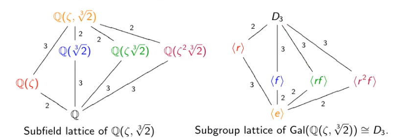

*Image credit to [Visual Group Theory Lectures by Professor Macauley](https://youtu.be/8qkfW35AqrQ?si=kM7dqAP33u8rWWn9)*

[Home Page](http://rinterested.github.io/statistics/index.html)

**NOTE: These are tentative notes on different topics for personal use - expect mistakes and misunderstandings.**